# GLDS-136 Analysis Using iDEP 0.91

Hyun-seok ‘Ren’ Chang

Sat Jul 25 09:49:05 2020

Analysis of [GLDS-136](https://genelab-data.ndc.nasa.gov/genelab/accession/GLDS-136/) from NASA GeneLab

This R markdown file was auto-generated by the [iDEP website](http://ge-lab.org/idep/) Using iDEP 0.91, originally by Steven Xijin.Ge@sdstate.edu

Ge SX, Son EW, Yao R: iDEP: an integrated web application for differential expression and pathway analysis of RNA-Seq data. BMC Bioinformatics 2018, 19(1):534. PMID:30567491

## 1. Read data

First we set up the working directory to where the files are saved.

```r
 setwd('~/Documents/HTML_R/GLDS136')
```

R packages and iDEP core Functions. Users can also download the iDEP_core_functions.R file. Many R packages needs to be installed first. This may take hours. Each of these packages took years to develop.So be a patient thief. Sometimes dependencies needs to be installed manually. If you are using an older version of R, and having trouble with package installation, try un-install the current version of R, delete all folders and files (C:/Program Files/R/R-3.4.3), and reinstall from scratch.

```r
 if(file.exists('iDEP_core_functions.R'))
    source('iDEP_core_functions.R') else
    source('https://raw.githubusercontent.com/iDEP-SDSU/idep/master/shinyapps/idep/iDEP_core_functions.R')
```

We are using the downloaded gene expression file where gene IDs has been converted to Ensembl gene IDs. This is because the ID conversion database is too large to download. You can use your original file if your file uses Ensembl ID, or you do not want to use the pathway files available in iDEP (or it is not available).

```r
 inputFile <- 'GLDS136_Expression.csv'
 sampleInfoFile <- 'GLDS136_Sampleinfo.csv'
 gldsMetadataFile <- 'GLDS136_Metadata.csv'
 geneInfoFile <- 'Arabidopsis_thaliana__athaliana_eg_gene_GeneInfo.csv' #Gene symbols, location etc.
 geneSetFile <- 'Arabidopsis_thaliana__athaliana_eg_gene.db'  # pathway database in SQL; can be GMT format
 STRING10_speciesFile <- 'https://raw.githubusercontent.com/iDEP-SDSU/idep/master/shinyapps/idep/STRING10_species.csv'
```

Parameters for reading data

```r
 input_missingValue <- 'geneMedian' #Missing values imputation method
 input_dataFileFormat <- 1  #1- read counts, 2 FKPM/RPKM or DNA microarray
 input_minCounts <- 0.5 #Min counts
 input_NminSamples <- 1 #Minimum number of samples
 input_countsLogStart <- 4  #Pseudo count for log CPM
 input_CountsTransform <- 1 #Methods for data transformation of counts. 1-EdgeR's logCPM 2-VST, 3-rlog
```

```r
readMetadata.out <- readMetadata(gldsMetadataFile)
library(knitr)   #  install if needed. for showing tables with kable
library(kableExtra)
kable( readMetadata.out ) %>%
  kable_styling(bootstrap_options = c("striped", "hover")) %>%
  scroll_box(width = "100%")
```

|  | X50kPa_notsuppO2_Rep1 | X50kPa_notsuppO2_Rep2 | X50kPa_notsuppO2_Rep3 | X50kPa_suppO2_Rep1 | X50kPa_suppO2_Rep2 | X50kPa_suppO2_Rep3 | X97kPa_CTRL_Rep1 | X97kPa_CTRL_Rep2 | X97kPa_CTRL_Rep3 |
| --- | --- | --- | --- | --- | --- | --- | --- | --- | --- |
| Sample.LongId | Atha.Ws.0.root.50kPa.notsuppO2.Rep1.Array | Atha.Ws.0.root.50kPa.notsuppO2.Rep2.Array | Atha.Ws.0.root.50kPa.notsuppO2.Rep3.Array | Atha.Ws.0.root.50kPa.suppO2.Rep1.Array | Atha.Ws.0.root.50kPa.suppO2.Rep2.Array | Atha.Ws.0.root.50kPa.suppO2.Rep3.Array | Atha.Ws.0.root.97kPa.CTRL.Rep1.Array | Atha.Ws.0.root.97kPa.CTRL.Rep2.Array | Atha.Ws.0.root.97kPa.CTRL.Rep3.Array |
| Sample.Id | Atha.Ws.0.root.50kPa.notsuppO2.Rep1 | Atha.Ws.0.root.50kPa.notsuppO2.Rep2 | Atha.Ws.0.root.50kPa.notsuppO2.Rep3 | Atha.Ws.0.root.50kPa.suppO2.Rep1 | Atha.Ws.0.root.50kPa.suppO2.Rep2 | Atha.Ws.0.root.50kPa.suppO2.Rep3 | Atha.Ws.0.root.97kPa.CTRL.Rep1 | Atha.Ws.0.root.97kPa.CTRL.Rep2 | Atha.Ws.0.root.97kPa.CTRL.Rep3 |
| Sample.Name | Atha_Ws-0_root_50kPa_notsuppO2_Rep1 | Atha_Ws-0_root_50kPa_notsuppO2_Rep2 | Atha_Ws-0_root_50kPa_notsuppO2_Rep3 | Atha_Ws-0_root_50kPa_suppO2_Rep1 | Atha_Ws-0_root_50kPa_suppO2_Rep2 | Atha_Ws-0_root_50kPa_suppO2_Rep3 | Atha_Ws-0_root_97kPa_CTRL_Rep1 | Atha_Ws-0_root_97kPa_CTRL_Rep2 | Atha_Ws-0_root_97kPa_CTRL_Rep3 |
| GLDS | 136 | 136 | 136 | 136 | 136 | 136 | 136 | 136 | 136 |
| Accession | GLDS-136 | GLDS-136 | GLDS-136 | GLDS-136 | GLDS-136 | GLDS-136 | GLDS-136 | GLDS-136 | GLDS-136 |
| Hardware | Petri dish | Petri dish | Petri dish | Petri dish | Petri dish | Petri dish | Petri dish | Petri dish | Petri dish |
| Tissue | Roots | Roots | Roots | Roots | Roots | Roots | Roots | Roots | Roots |
| Age | 5 days | 5 days | 5 days | 5 days | 5 days | 5 days | 5 days | 5 days | 5 days |
| Organism | Arabidopsis thaliana | Arabidopsis thaliana | Arabidopsis thaliana | Arabidopsis thaliana | Arabidopsis thaliana | Arabidopsis thaliana | Arabidopsis thaliana | Arabidopsis thaliana | Arabidopsis thaliana |
| Ecotype | WS-0 | WS-0 | WS-0 | WS-0 | WS-0 | WS-0 | WS-0 | WS-0 | WS-0 |
| Genotype | WT | WT | WT | WT | WT | WT | WT | WT | WT |
| Variety | WS-0 WT | WS-0 WT | WS-0 WT | WS-0 WT | WS-0 WT | WS-0 WT | WS-0 WT | WS-0 WT | WS-0 WT |
| Radiation | Background Earth | Background Earth | Background Earth | Background Earth | Background Earth | Background Earth | Background Earth | Background Earth | Background Earth |
| Gravity | Terrestrial | Terrestrial | Terrestrial | Terrestrial | Terrestrial | Terrestrial | Terrestrial | Terrestrial | Terrestrial |
| Developmental | 10 day old seedling, 2 rosette leaves gt1 mm in length | 10 day old seedling, 2 rosette leaves gt1 mm in length | 10 day old seedling, 2 rosette leaves gt1 mm in length | 10 day old seedling, 2 rosette leaves gt1 mm in length | 10 day old seedling, 2 rosette leaves gt1 mm in length | 10 day old seedling, 2 rosette leaves gt1 mm in length | 10 day old seedling, 2 rosette leaves gt1 mm in length | 10 day old seedling, 2 rosette leaves gt1 mm in length | 10 day old seedling, 2 rosette leaves gt1 mm in length |
| Time.series.or.Concentration.gradient | Single time point | Single time point | Single time point | Single time point | Single time point | Single time point | Single time point | Single time point | Single time point |
| Light | White light | White light | White light | White light | White light | White light | White light | White light | White light |
| Assay..RNAseq. | Microarray Transcription Profiling | Microarray Transcription Profiling | Microarray Transcription Profiling | Microarray Transcription Profiling | Microarray Transcription Profiling | Microarray Transcription Profiling | Microarray Transcription Profiling | Microarray Transcription Profiling | Microarray Transcription Profiling |
| Temperature | Ambient Terrestrial | Ambient Terrestrial | Ambient Terrestrial | Ambient Terrestrial | Ambient Terrestrial | Ambient Terrestrial | Ambient Terrestrial | Ambient Terrestrial | Ambient Terrestrial |
| Treatment.type | 50kPa_Low pressure | 50kPa_Low pressure | 50kPa_Low pressure | 50kPa_Low pressure | 50kPa_Low pressure | 50kPa_Low pressure | Ambient pressure | Ambient pressure | Ambient pressure |
| Treatment.intensity | 50kPa_notsuppO2 | 50kPa_notsuppO2 | 50kPa_notsuppO2 | 50kPa_suppO2 | 50kPa_suppO2 | 50kPa_suppO2 | Ambient kPA &O2 | Ambient kPA &O2 | Ambient kPA &O2 |
| Treament.timing | x | x | x | x | x | x | x | x | x |
| Preservation.Method. | NA | NA | NA | NA | NA | NA | NA | NA | NA |

```r
 readData.out <- readData(inputFile)
   kable( head(readData.out$data) ) %>%
  kable_styling(bootstrap_options = c("striped", "hover")) %>%
  scroll_box(width = "100%")
```

|  | X50kPa_notsuppO2_Rep1 | X50kPa_notsuppO2_Rep2 | X50kPa_notsuppO2_Rep3 | X50kPa_suppO2_Rep1 | X50kPa_suppO2_Rep2 | X50kPa_suppO2_Rep3 | X97kPa_CTRL_Rep1 | X97kPa_CTRL_Rep2 | X97kPa_CTRL_Rep3 |
| --- | --- | --- | --- | --- | --- | --- | --- | --- | --- |
| AT4G33560 | 3.459432 | 3.459432 | 3.459432 | 3.169925 | 3.000000 | 2.807355 | 3.000000 | 3.000000 | 2.807355 |
| AT1G43800 | 3.459432 | 3.321928 | 3.321928 | 3.000000 | 2.807355 | 2.807355 | 2.807355 | 2.807355 | 2.807355 |
| AT1G24020 | 3.700440 | 3.700440 | 3.700440 | 3.584963 | 3.700440 | 3.321928 | 3.169925 | 3.321928 | 3.321928 |
| AT4G33070 | 3.321928 | 3.169925 | 3.321928 | 2.584963 | 2.807355 | 2.807355 | 2.807355 | 2.807355 | 2.807355 |
| AT4G10270 | 3.459432 | 3.459432 | 3.584963 | 3.321928 | 3.169925 | 3.169925 | 3.169925 | 3.169925 | 3.000000 |
| AT4G27450 | 3.459432 | 3.459432 | 3.459432 | 3.321928 | 3.169925 | 3.169925 | 3.169925 | 3.169925 | 3.169925 |

```r
 readSampleInfo.out <- readSampleInfo(sampleInfoFile)
 kable( readSampleInfo.out ) %>%
  kable_styling(bootstrap_options = c("striped", "hover")) %>%
  scroll_box(width = "100%")
```

|  | Treatment.type | Treatment.intensity |
| --- | --- | --- |
| X50kPa_notsuppO2_Rep1 | 50kPa_Low pressure | 50kPa_notsuppO2 |
| X50kPa_notsuppO2_Rep2 | 50kPa_Low pressure | 50kPa_notsuppO2 |
| X50kPa_notsuppO2_Rep3 | 50kPa_Low pressure | 50kPa_notsuppO2 |
| X50kPa_suppO2_Rep1 | 50kPa_Low pressure | 50kPa_suppO2 |
| X50kPa_suppO2_Rep2 | 50kPa_Low pressure | 50kPa_suppO2 |
| X50kPa_suppO2_Rep3 | 50kPa_Low pressure | 50kPa_suppO2 |
| X97kPa_CTRL_Rep1 | Ambient_pressure | Control |
| X97kPa_CTRL_Rep2 | Ambient_pressure | Control |
| X97kPa_CTRL_Rep3 | Ambient_pressure | Control |

```r
 input_selectOrg ="NEW"
 input_selectGO <- NULL     #Gene set category
 input_noIDConversion = TRUE
 allGeneInfo.out <- geneInfo(geneInfoFile)
 converted.out = NULL
 convertedData.out <- convertedData()
 nGenesFilter()
```

```
## [1] "16156 genes in 9 samples. 16156  genes passed filter.\n Original gene IDs used."
```

```r
 convertedCounts.out <- convertedCounts()  # converted counts, just for compatibility
```

## 2. Pre-process

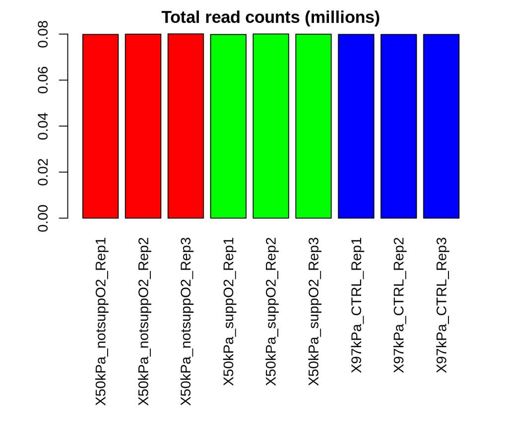

```r
# Read counts per library
 parDefault = par()
 par(mar=c(12,4,2,2))
 # barplot of total read counts
 x <- readData.out$rawCounts
 groups = as.factor( detectGroups(colnames(x ) ) )
 if(nlevels(groups)<=1 | nlevels(groups) >20 )
  col1 = 'green'  else
  col1 = rainbow(nlevels(groups))[ groups ]

 barplot( colSums(x)/1e6,
        col=col1,las=3, main="Total read counts (millions)")
```

```r
 readCountsBias()  # detecting bias in sequencing depth
```

```
## [1] 0.3016098
## [1] 0.1161916
## [1] 0.3016098
```

```
## [1] "No bias detected"
```

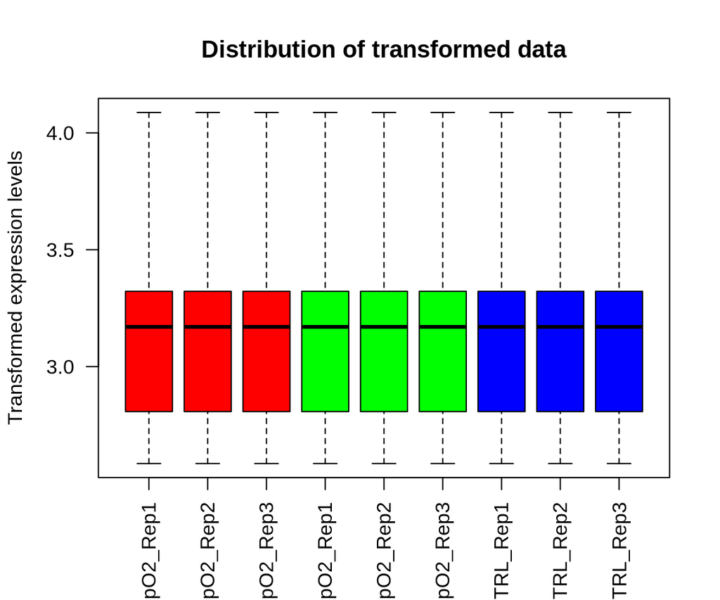

```r
 # Box plot
 x = readData.out$data
 boxplot(x, las = 2, col=col1,
    ylab='Transformed expression levels',
    main='Distribution of transformed data')
```

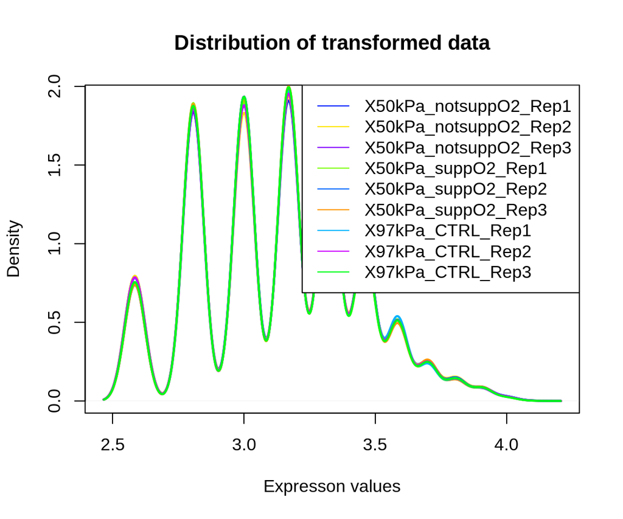

```r
 #Density plot
 par(parDefault)
 densityPlot()
```

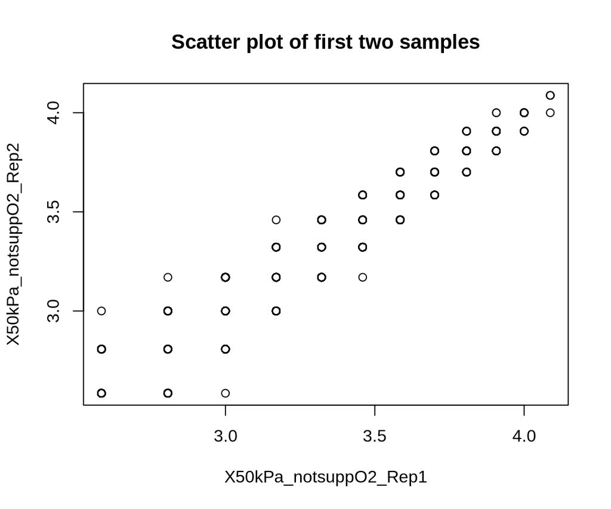

```r
 # Scatter plot of the first two samples
 plot(x[,1:2],xlab=colnames(x)[1],ylab=colnames(x)[2],
    main='Scatter plot of first two samples')
```

```r
 ####plot gene or gene family
 input_selectOrg ="BestMatch"
 input_geneSearch <- 'HOXA' #Gene ID for searching
 genePlot()
```

[output not shown]

```r
 input_useSD <- 'FALSE' #Use standard deviation instead of standard error in error bar?
 geneBarPlotError()
```

[output not shown]

## 3. Heatmap

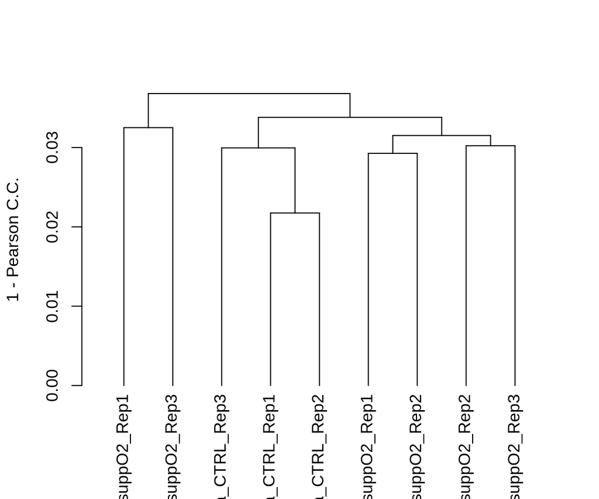

```r
 # hierarchical clustering tree
 x <- readData.out$data
 maxGene <- apply(x,1,max)
 # remove bottom 25% lowly expressed genes, which inflate the PPC
 x <- x[which(maxGene > quantile(maxGene)[1] ) ,]
 plot(as.dendrogram(hclust2( dist2(t(x)))), ylab="1 - Pearson C.C.", type = "rectangle")
```

```r
 #Correlation matrix
 input_labelPCC <- TRUE #Show correlation coefficient?
 correlationMatrix()
```

[figure not shown]

```r
 # Parameters for heatmap
 input_nGenes <- 500    #Top genes for heatmap
 input_geneCentering <- TRUE    #centering genes ?
 input_geneNormalize <- FALSE   #Normalize by gene?
 input_sampleNormalize <- FALSE #Normalize by sample?
 input_noSampleClustering <- FALSE  #Use original sample order
 input_heatmapCutoff <- 4   #Remove outliers beyond number of SDs
 input_distFunctions <- 1   #which distant funciton to use
 input_hclustFunctions <- 1 #Linkage type
 input_heatColors1 <- 1 #Colors
 input_selectFactorsHeatmap <- NULL     #Sample coloring factors
 png('heatmap.png', width = 10, height = 15, units = 'in', res = 300)
 staticHeatmap()
```

[output not shown]

```r
 dev.off()
```

```r
 heatmapPlotly() # interactive heatmap using Plotly
```

[output not shown]

## 4. K-means clustering

```r
 input_nGenesKNN <- 2000    #Number of genes fro k-Means
 input_nClusters <- 4   #Number of clusters
 maxGeneClustering = 12000
 input_kmeansNormalization <- 'geneMean'    #Normalization
 input_KmeansReRun <- 0 #Random seed

 distributionSD()  #Distribution of standard deviations
```

[figure not shown]

```r
 KmeansNclusters()  #Number of clusters
```

[figure not shown]

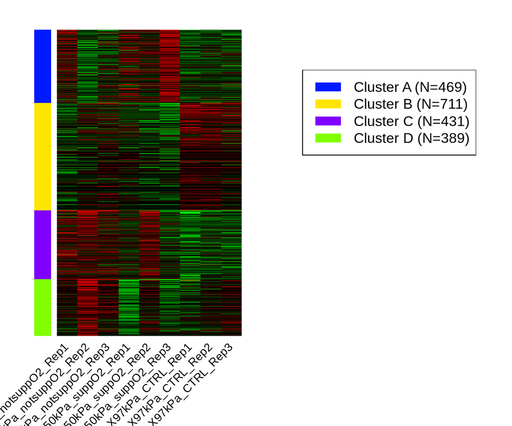

```r
 Kmeans.out = Kmeans()   #Running K-means
 KmeansHeatmap()   #Heatmap for k-Means
```

```r
 #Read gene sets for enrichment analysis
 sqlite  <- dbDriver('SQLite')
 input_selectGO3 <- NULL    #Gene set category
 input_minSetSize <- 15 #Min gene set size
 input_maxSetSize <- 2000   #Max gene set size
 GeneSets.out <-readGeneSets( geneSetFile,
    convertedData.out, input_selectGO3,input_selectOrg,
    c(input_minSetSize, input_maxSetSize)  )
 # Alternatively, users can use their own GMT files by
 #GeneSets.out <- readGMTRobust('somefile.GMT')
 results <- KmeansGO()  #Enrichment analysis for k-Means clusters
 results$adj.Pval <- format( results$adj.Pval,digits=3 )
 kable( results, row.names=FALSE) %>%
  kable_styling(bootstrap_options = c("striped", "hover")) %>%
  scroll_box(width = "100%")
```

| Cluster | adj.Pval | Genes | Pathways |
| --- | --- | --- | --- |
| A | 3.33e-18 | 47 | Cell wall organization or biogenesis |
|  | 3.31e-16 | 39 | Cell wall organization |
|  | 1.45e-15 | 39 | External encapsulating structure organization |
|  | 2.45e-13 | 27 | Root morphogenesis |
|  | 7.67e-13 | 21 | Plant-type cell wall organization |
|  | 8.63e-13 | 17 | Antibiotic catabolic process |
|  | 8.63e-13 | 35 | Root system development |
|  | 8.63e-13 | 16 | Hydrogen peroxide catabolic process |
|  | 8.63e-13 | 35 | Root development |
|  | 8.63e-13 | 61 | Oxidation-reduction process |
| B | 7.53e-19 | 98 | Response to hormone |
|  | 1.28e-18 | 98 | Response to endogenous stimulus |
|  | 4.50e-18 | 107 | Response to organic substance |
|  | 1.08e-17 | 104 | Transcription, DNA-templated |
|  | 1.08e-17 | 105 | RNA biosynthetic process |
|  | 1.35e-17 | 104 | Nucleic acid-templated transcription |
|  | 2.14e-16 | 114 | Nucleobase-containing compound biosynthetic process |
|  | 4.31e-16 | 97 | Regulation of transcription, DNA-templated |
|  | 4.87e-16 | 97 | Regulation of nucleic acid-templated transcription |
|  | 4.87e-16 | 97 | Regulation of RNA biosynthetic process |
| C | 2.64e-26 | 96 | Response to abiotic stimulus |
|  | 2.10e-17 | 30 | Photosynthesis |
|  | 3.49e-15 | 25 | Cellular response to decreased oxygen levels |
|  | 3.49e-15 | 25 | Cellular response to oxygen levels |
|  | 3.49e-15 | 25 | Cellular response to hypoxia |
|  | 4.35e-15 | 62 | Oxidation-reduction process |
|  | 3.35e-14 | 44 | Peptide metabolic process |
|  | 3.38e-14 | 25 | Response to hypoxia |
|  | 4.32e-14 | 25 | Response to decreased oxygen levels |
|  | 4.38e-14 | 25 | Response to oxygen levels |
| D | 3.66e-103 | 87 | Photosynthesis |
|  | 2.82e-65 | 53 | Photosynthesis, light reaction |
|  | 1.16e-50 | 66 | Generation of precursor metabolites and energy |
|  | 7.62e-31 | 24 | Photosynthetic electron transport chain |
|  | 1.37e-24 | 32 | Electron transport chain |
|  | 1.51e-24 | 87 | Response to abiotic stimulus |
|  | 9.95e-24 | 71 | Oxidation-reduction process |
|  | 2.14e-18 | 44 | Response to light stimulus |
|  | 2.14e-18 | 15 | Photosynthesis, light harvesting |
|  | 2.70e-18 | 16 | Protein-chromophore linkage |

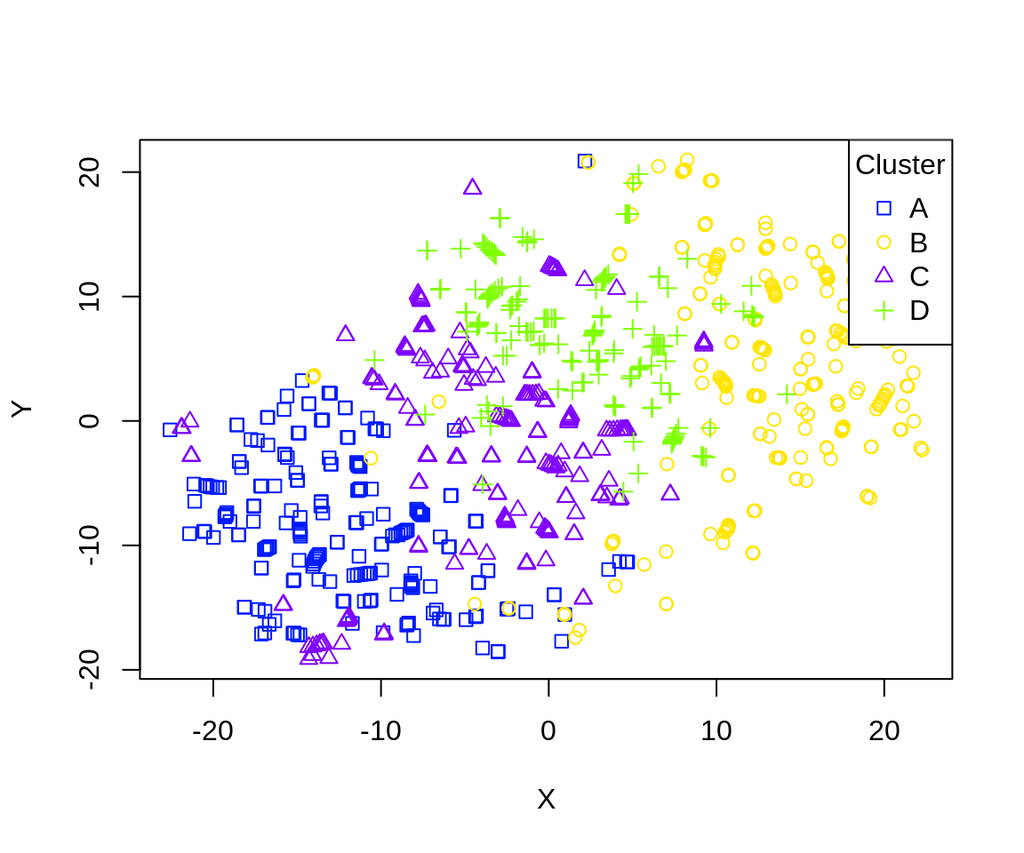

```r
 input_seedTSNE <- 0    #Random seed for t-SNE
 input_colorGenes <- TRUE   #Color genes in t-SNE plot?
 tSNEgenePlot()  #Plot genes using t-SNE
```

## 5. PCA and beyond

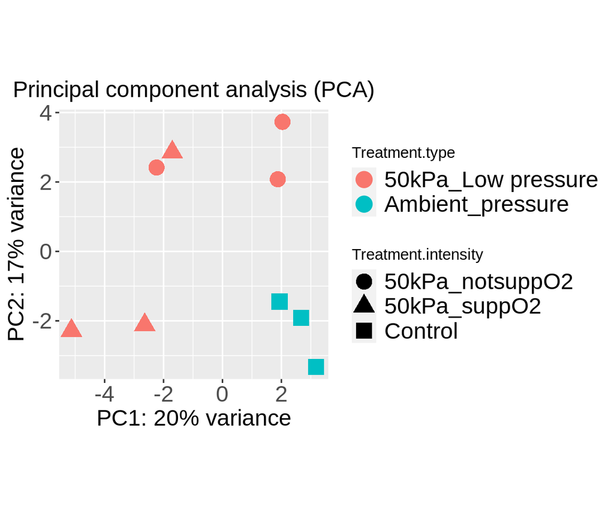

```r
 input_selectFactors <- 'Treatment.type'    #Factor coded by color
 input_selectFactors2 <- 'Treatment.intensity'  #Factor coded by shape
 input_tsneSeed2 <- 0   #Random seed for t-SNE
 #PCA, MDS and t-SNE plots
 PCAplot()
```

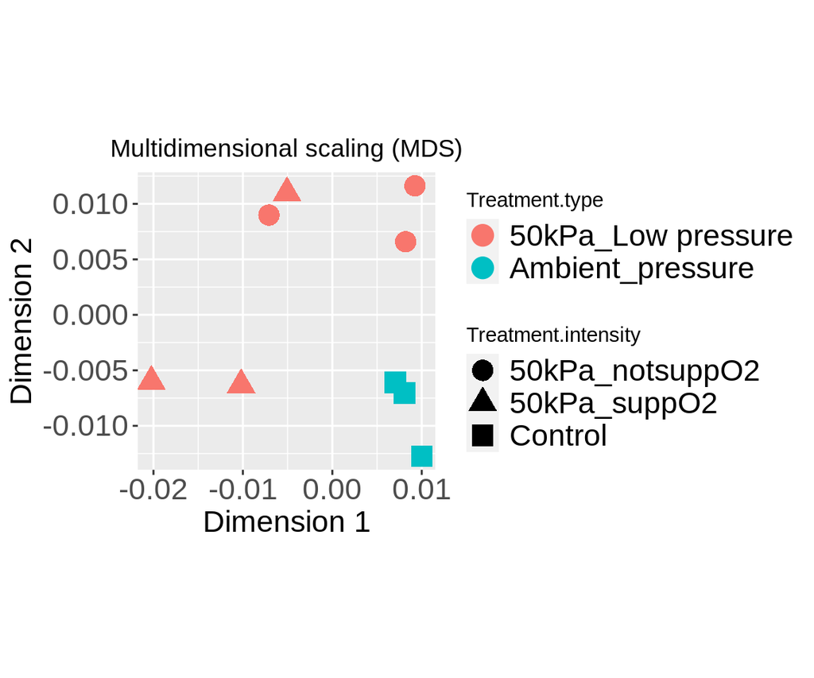

```r
 MDSplot()
```

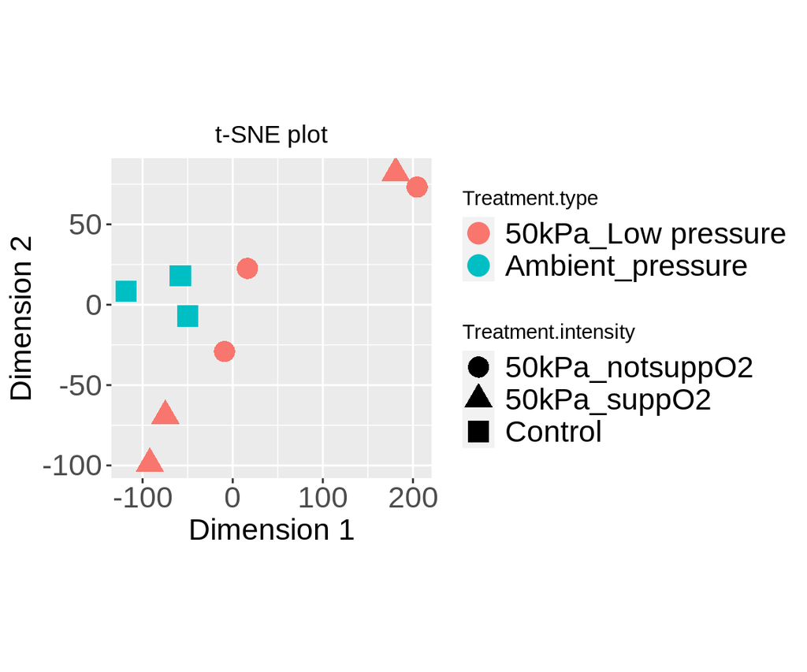

```r
 tSNEplot()
```

```r
 #Read gene sets for pathway analysis using PGSEA on principal components
 input_selectGO6 <- 'GOBP'
 GeneSets.out <-readGeneSets( geneSetFile,
    convertedData.out, input_selectGO6,input_selectOrg,
    c(input_minSetSize, input_maxSetSize)  )
 PCApathway() # Run PGSEA analysis
```

[figure not shown]

```r
 cat( PCA2factor() )   #The correlation between PCs with factors
```

[output not shown]

## 6. DEG1

```r
 input_CountsDEGMethod <- 2 #DESeq2= 3,limma-voom=2,limma-trend=1
 input_limmaPval <- 0.1 #FDR cutoff
 input_limmaFC <- 2 #Fold-change cutoff
 input_selectModelComprions <- 'Treatment.type: 50kPa_Low pressure vs. Ambient_pressure'    #Selected comparisons
 input_selectFactorsModel <- 'Treatment.type'   #Selected comparisons
 input_selectInteractions <- NULL   #Selected comparisons
 input_selectBlockFactorsModel <- NULL  #Selected comparisons
 factorReferenceLevels.out <- c('Treatment.type:50kPa_Low pressure')

 limma.out <- limma()
```

[output not shown]

```r
 DEG.data.out <- DEG.data()
```

[output not shown]

```r
 limma.out$comparisons
```

[output not shown]

```r
 input_selectComparisonsVenn = limma.out$comparisons[1:3] # use first three comparisons
```

[output not shown]

```r
 input_UpDownRegulated <- FALSE #Split up and down regulated genes
 vennPlot() # Venn diagram
```

[output not shown]

```r
  sigGeneStats() # number of DEGs as figure
```

[output not shown]

```r
  sigGeneStatsTable() # number of DEGs as table
```

[output not shown]

## 7. DEG2

```r
 input_selectContrast = limma.out$comparisons[1] # use first  comparisons
```

[output not shown]

```r
 selectedHeatmap.data.out <- selectedHeatmap.data()
```

[output not shown]

```r
 selectedHeatmap()   # heatmap for DEGs in selected comparison
```

[output not shown]

```r
 # Save gene lists and data into files
 write.csv( selectedHeatmap.data()$genes, 'heatmap.data.csv')
```

[output not shown]

```r
 write.csv(DEG.data(),'DEG.data.csv' )
```

[output not shown]

```r
 write(AllGeneListsGMT() ,'AllGeneListsGMT.gmt')
```

[output not shown]

```r
 input_selectGO2 <- 'GOBP'  #Gene set category
 geneListData.out <- geneListData()
```

[output not shown]

```r
 volcanoPlot()
```

[output not shown]

```r
  scatterPlot()
```

[output not shown]

```r
  MAplot()
```

[output not shown]

```r
  geneListGOTable.out <- geneListGOTable()
```

[output not shown]

```r
 # Read pathway data again
 GeneSets.out <-readGeneSets( geneSetFile,
    convertedData.out, input_selectGO2,input_selectOrg,
    c(input_minSetSize, input_maxSetSize)  )
 input_removeRedudantSets <- TRUE   #Remove highly redundant gene sets?
 results <- geneListGO()  #Enrichment analysis
```

[output not shown]

```r
 results$adj.Pval <- format( results$adj.Pval,digits=3 )
 kable( results, row.names=FALSE) %>%
  kable_styling(bootstrap_options = c("striped", "hover")) %>%
  scroll_box(width = "100%")
```

[output not shown]

STRING-db API access. We need to find the taxonomy id of your species, this used by STRING. First we try to guess the ID based on iDEP’s database. Users can also skip this step and assign NCBI taxonomy id directly by findTaxonomyID.out = 10090 # mouse 10090, human 9606 etc.

```r
 STRING10_species = read.csv(STRING10_speciesFile)
 ix = grep('Arabidopsis thaliana', STRING10_species$official_name )
 findTaxonomyID.out <- STRING10_species[ix,1] # find taxonomyID
 findTaxonomyID.out
```

```
## [1] 3702
```

Enrichment analysis using STRING

```r
  STRINGdb_geneList.out <- STRINGdb_geneList() #convert gene lists
```

[output not shown]

```r
 input_STRINGdbGO <- 'Process'  #'Process', 'Component', 'Function', 'KEGG', 'Pfam', 'InterPro'
 results <- stringDB_GO_enrichmentData()  # enrichment using STRING
```

[output not shown]

```r
 results$adj.Pval <- format( results$adj.Pval,digits=3 )
 kable( results, row.names=FALSE) %>%
  kable_styling(bootstrap_options = c("striped", "hover")) %>%
  scroll_box(width = "100%")
```

[output not shown]

PPI network retrieval and analysis

```r
 input_nGenesPPI <- 100 #Number of top genes for PPI retrieval and analysis
 stringDB_network1(1) #Show PPI network
```

[output not shown]

Generating interactive PPI

```r
 write(stringDB_network_link(), 'PPI_results.html') # write results to html file
```

[output not shown]

```r
 browseURL('PPI_results.html') # open in browser
```

## 8. Pathway analysis

```r
 input_selectContrast1 = limma.out$comparisons[1]
```

[output not shown]

```r
 #input_selectContrast1 = limma.out$comparisons[3] # manually set
 input_selectGO = 'GOBP'  # gene set category
 #input_selectGO='custom' # if custom gmt file
 input_minSetSize <- 15 #Min size for gene set
 input_maxSetSize <- 2000   #Max size for gene set
 # Read pathway data again
 GeneSets.out <-readGeneSets( geneSetFile,
    convertedData.out, input_selectGO,input_selectOrg,
    c(input_minSetSize, input_maxSetSize)  )
 input_pathwayPvalCutoff <- 0.2 #FDR cutoff
 input_nPathwayShow <- 30   #Top pathways to show
 input_absoluteFold <- FALSE    #Use absolute values of fold-change?
 input_GenePvalCutoff <- 1  #FDR to remove genes

 input_pathwayMethod = 1  # 1  GAGE
 gagePathwayData.out <- gagePathwayData()  # pathway analysis using GAGE
```

[output not shown]

```r
 results <- gagePathwayData.out  #Enrichment analysis for k-Means clusters
```

[output not shown]

```r
 results$adj.Pval <- format( results$adj.Pval,digits=3 )
 kable( results, row.names=FALSE) %>%
  kable_styling(bootstrap_options = c("striped", "hover")) %>%
  scroll_box(width = "100%")
```

[output not shown]

```r
 pathwayListData.out = pathwayListData()
```

[output not shown]

```r
 enrichmentPlot(pathwayListData.out, 25  )
```

[output not shown]

```r
  enrichmentNetwork(pathwayListData.out )
```

[output not shown]

```r
  enrichmentNetworkPlotly(pathwayListData.out)
```

[output not shown]

```r
 input_pathwayMethod = 3  # 1  fgsea
 fgseaPathwayData.out <- fgseaPathwayData() #Pathway analysis using fgsea
```

[output not shown]

```r
 results <- fgseaPathwayData.out  #Enrichment analysis for k-Means clusters
```

[output not shown]

```r
 results$adj.Pval <- format( results$adj.Pval,digits=3 )
 kable( results, row.names=FALSE) %>%
  kable_styling(bootstrap_options = c("striped", "hover")) %>%
  scroll_box(width = "100%")
```

[output not shown]

```r
  pathwayListData.out = pathwayListData()
```

[output not shown]

```r
 enrichmentPlot(pathwayListData.out, 25  )
```

[output not shown]

```r
  enrichmentNetwork(pathwayListData.out )
```

[output not shown]

```r
  enrichmentNetworkPlotly(pathwayListData.out)
```

[output not shown]

```r
   PGSEAplot() # pathway analysis using PGSEA
```

[output not shown]

## 9. Chromosome

```r
 input_selectContrast2 = limma.out$comparisons[1]
```

[output not shown]

```r
 #input_selectContrast2 = limma.out$comparisons[3] # manually set
 input_limmaPvalViz <- 0.1  #FDR to filter genes
 input_limmaFCViz <- 2  #FDR to filter genes
 genomePlotly() # shows fold-changes on the genome
```

[output not shown]

## 10. Biclustering

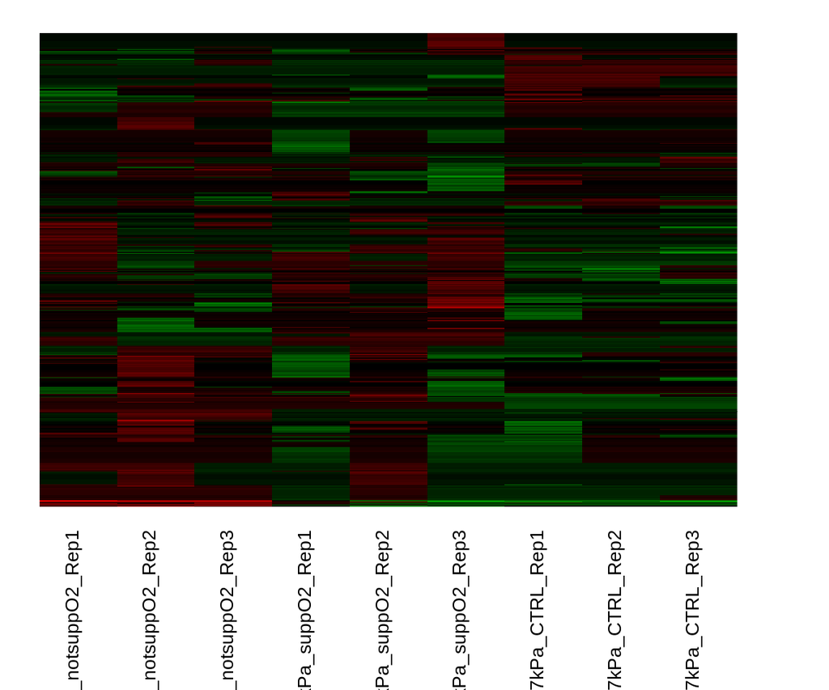

```r
 input_nGenesBiclust <- 1000    #Top genes for biclustering
 input_biclustMethod <- 'BCCC()'    #Method: 'BCCC', 'QUBIC', 'runibic' ...
 biclustering.out = biclustering()  # run analysis

 input_selectBicluster <- 1 #select a cluster
 biclustHeatmap()   # heatmap for selected cluster
```

```r
 input_selectGO4 <- 'GOBP'  #Gene set category
 # Read pathway data again
 GeneSets.out <-readGeneSets( geneSetFile,
    convertedData.out, input_selectGO4,input_selectOrg,
    c(input_minSetSize, input_maxSetSize)  )
 results <- geneListBclustGO()  #Enrichment analysis for k-Means clusters
 results$adj.Pval <- format( results$adj.Pval,digits=3 )
 kable( results, row.names=FALSE) %>%
  kable_styling(bootstrap_options = c("striped", "hover")) %>%
  scroll_box(width = "100%")
```

| adj.Pval | Genes | Pathways |
| --- | --- | --- |
| 1.4e-76 | 95 | Photosynthesis |
| 6.1e-46 | 55 | Photosynthesis, light reaction |
| 6.6e-45 | 156 | Oxidation-reduction process |
| 2.2e-37 | 178 | Response to abiotic stimulus |
| 6.3e-31 | 73 | Generation of precursor metabolites and energy |
| 1.5e-29 | 140 | Response to hormone |
| 2.1e-29 | 141 | Response to endogenous stimulus |
| 1.9e-27 | 152 | Response to organic substance |
| 2.5e-26 | 127 | Cellular response to chemical stimulus |
| 1.7e-24 | 26 | Photosynthetic electron transport chain |

## 11. Co-expression network

```r
 input_mySoftPower <- 5 #SoftPower to cutoff
 input_nGenesNetwork <- 1000    #Number of top genes
 input_minModuleSize <- 20  #Module size minimum
 wgcna.out = wgcna()   # run WGCNA
```

```
##    Power SFT.R.sq   slope truncated.R.sq mean.k. median.k. max.k.
## 1      1   0.2610  4.2500         0.3990   361.0     368.0  471.0
## 2      2   0.2570  3.2500         0.0932   186.0     187.0  288.0
## 3      3   0.3630  0.8780         0.4100   112.0     113.0  197.0
## 4      4   0.0224  0.2760         0.5080    74.9      74.3  143.0
## 5      5   0.2090  0.4120         0.5790    54.3      55.1  107.0
## 6      6   0.3370  0.3680         0.7830    41.9      40.3   81.9
## 7      7   0.0220  0.0755         0.5380    34.0      31.5   70.6
## 8      8   0.0237 -0.0747         0.4190    28.8      27.4   63.5
## 9      9   0.1170 -0.2850         0.0504    25.2      22.3   58.6
## 10    10   0.1280 -0.5370        -0.1170    22.7      20.4   55.0
## 11    12   0.4720 -0.4720         0.3490    19.5      17.0   50.6
## 12    14   0.4950 -0.5640         0.3530    17.7      14.7   48.1
## 13    16   0.5740 -0.6050         0.4540    16.7      13.7   46.6
## 14    18   0.6010 -0.6260         0.4980    16.0      12.8   45.7
## 15    20   0.6020 -0.6160         0.5060    15.6      11.9   45.1
## TOM calculation: adjacency..
## ..will not use multithreading.
##  Fraction of slow calculations: 0.000000
## ..connectivity..
## ..matrix multiplication (system BLAS)..
## ..normalization..
## ..done.
```

[output not shown]

```r
 softPower()  # soft power curve
```

[output not shown]

```r
  modulePlot()  # plot modules
```

[output not shown]

```r
  listWGCNA.Modules.out = listWGCNA.Modules() #modules
```

[output not shown]

```r
 input_selectGO5 <- 'GOBP'  #Gene set category
 # Read pathway data again
 GeneSets.out <-readGeneSets( geneSetFile,
    convertedData.out, input_selectGO5,input_selectOrg,
    c(input_minSetSize, input_maxSetSize)  )
 input_selectWGCNA.Module <- 'Entire network'   #Select a module
 input_topGenesNetwork <- 10    #SoftPower to cutoff
 input_edgeThreshold <- 0.4 #Number of top genes
 moduleNetwork()    # show network of top genes in selected module
```

[output not shown]

```r
 input_removeRedudantSets <- TRUE   #Remove redundant gene sets
 results <- networkModuleGO()  #Enrichment analysis of selected module
```

[output not shown]

```r
 results$adj.Pval <- format( results$adj.Pval,digits=3 )
 kable( results, row.names=FALSE) %>%
  kable_styling(bootstrap_options = c("striped", "hover")) %>%
  scroll_box(width = "100%")
```

[output not shown]